# Repeated Interaction

with Connor T. Wiegand

## Last Time

### Infinitely Repeated Games

- Play PD repeatedly

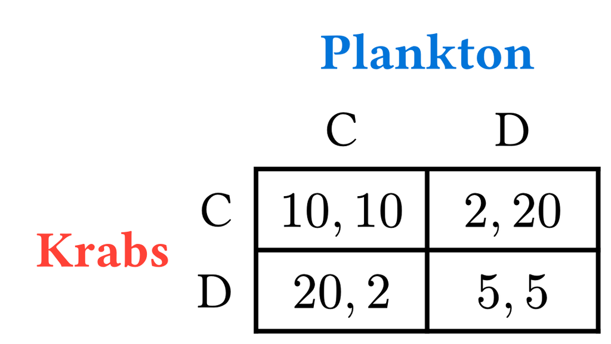

- Motivation:
  1. The game continues tomorrow with prob. $\delta$, ends forever with prob. $1-\delta$
  2. We are infinitely lived agents, but we discount the future by a factor of $\delta$
     - Later, we may think that each player could have a different $\delta$, which makes the second interpretation more versatile

### Math

- The geometric series
  $$\begin{aligned}
  \sum_{k=0}^{\infty} x^{n} &= 1 + x + x^2 + \cdots\\
  & = \frac{1}{1-x}
  \end{aligned}$$
- Note: we can multiply constants in and out of these sums
- E.g.
  $$\begin{aligned}
  \sum_{k=1}^{\infty} cx^{n} &= cx + cx^2 + cx^3 + \cdots\\
  &= c\sum_{k=1}^{\infty} x^{n} = c\left(\frac{x}{1-x}\right)
  \end{aligned}$$

### G.T.

- Recall the so-called “Grim Trigger” strategy:
  $$s_{GT} = \begin{cases}
  C & \text{if } D\notin \mathcal{H}\\
  D & \text{otherwise}
  \end{cases}$$
- Let’s assume it’s day 1<sup>1</sup>, and, for simplicity, assume that your opponent is just playing $C$ all the time<sup>2</sup>
- What happens if you play $C$ all the time?

  $$\pi(\overline{C},\overline{C}) = 10 + 10\delta + 10 \delta^2 + 10 \delta^3 + \cdots$$
- From the POV of day 1, the prob. of getting to stage $k$ is $\delta^k$
- What is this payoff sum equal to?
[^1]: In fact, it’s equivalent assume it’s any day, and we have only cooperated thus far
[^2]: call this strategy $\overline{C}$

### Payoff of Infinite Cooperation

- Recall: $\delta\in(0,1)$
  $$\begin{aligned}
  \pi(\overline{C},\overline{C}) &= 10 + 10\delta + 10 \delta^2 + 10 \delta^3 + \cdots\\
  &= 10 (1 + \delta + \delta^2 + \delta^3 + \cdots)\\
  &= 10\sum_{k=0}^{\infty} \delta^k
  \end{aligned}$$
- It’s a geometric series!

$$\pi(\overline{C},\overline{C}) = 10\sum_{k=0}^{\infty} \delta^k = \frac{10}{1-\delta}$$

- In some classes, you might refer to this infinite stream of income using the term “present discounted value” (PDV)

### Payoff of Breaking Relationship

- Let’s consider another case: suppose I cheat you, but you don’t cheat me, on day 1, and then we defect every day thereafter
- Now what’s our PDV?
- $$\begin{aligned}
  \pi &= 20 + (5)\delta + (5) \delta^{2} + (5)\delta^3 + \cdots\\
  &= 20 + 5\sum_{k=1}^{\infty}\delta^{k}\\
  &= 20 + \frac{5\delta}{1-\delta}
  \end{aligned}$$
- Remark: if you can, please feel free to omit ones ($1$) when writing $1\cdot \delta$

### What are we doing again?

- What’s our goal?
  - See if we can enforce cooperative play in PD, in a subgame-perfect sense
- Proposition: this can be achieved, for certain ranges of $\delta$, if both players play grim trigger
1. Let’s say both players have cooperated thus far in the game. What happens if we both decide to cooperate tomorrow
   - That’s the same as $\pi(\overline{C}, \overline{C})$

$$\begin{aligned}
10 + 10\delta + 10 \delta^{2} + \cdots &= 10\sum_{k=0}^{\infty} \delta^k\\
&= \frac{10}{1-\delta}
\end{aligned}$$

### Defecting from G.T.

- Maintain the assumption that both players have cooperated thus far in the game. Now, what happens if I cheat my partner?

$$\begin{aligned}
20 + 5\delta + 5\delta^{2} + 5\delta^{3} + \cdots &= 20 + 5\sum_{k=1}^{\infty} \delta^k\\
&= 20 + \frac{5\delta}{1-\delta}
\end{aligned}$$

- When will I stick with G.T. (e.g. not deviate for a strictly higher payoff)?
  - When $\frac{10}{1-\delta} > 20 + \frac{5\delta}{1-\delta}$

### Defecting from G.T. (cont.)

$$\begin{aligned}
\frac{10}{1-\delta} &> 20 + \frac{5\delta}{1-\delta} \\
10 &> 20 (1-\delta) + 5\delta\\
10 &> 20 - 15\delta\\
15\delta &> 10\\
\delta&>\frac{10}{15}\\
\delta&>\frac{2}{3}
\end{aligned}$$

- What does this mean?

### Interpretation

- Given a history of cooperation,
  - 1. a *sufficiently patient* agent ($\delta > 0.66$) will rationally stick with G.T. going forward
  - 2. given a sufficiently high probability that the game will continue ($\delta > 0.66$), players rationally stick with G.T. going forward
- Are we done?
  - Unfortunately not

### Continue Defecting

- We also must consider histories where someone did already defect
- Assume we keep playing $s_{GT}$:

$$\begin{aligned}
\pi(s_{GT}, s_{GT}| \mathcal{H}) &= \pi(\overline{D}, \overline{D}) \\
&= 5 + 5\delta + 5\delta^2 + 5\delta^3 + \cdots\\
&=\sum_{k=0}^{\infty} 5\delta^{k}\\
&= \frac{5}{1-\delta}
\end{aligned}$$

### Forgive

- We also must consider histories where someone did already defect
- Assume instead that we forgive them, and switch to playing Cooperative today (but then revert to grim trigger forever). Now what does our payoff stream look like?

$$\begin{aligned}
2 + 5\delta + 5\delta^2 + 5\delta^3 + \cdots &= 2 + \sum_{k=1}^{\infty}5\delta^{k}\\
&= 2 + \frac{5\delta}{1-\delta}
\end{aligned}$$

- When will we maintain grim trigger?

### When to forgive?

- Maintain grim trigger if
  $$\begin{aligned}
  \frac{5}{1-\delta} > 2 + \frac{5\delta}{1-\delta}\\
  \frac{5}{1-\delta} - \frac{5\delta}{1-\delta} > 2 \\
  \frac{5(1-\delta)}{1-\delta} > 2 \\
  5 > 2
  \end{aligned}$$
- When will we mantain grim trigger (as opposed to forgiving?)
  - Always

### Remarks

- As a result of the One-shot Deviation principle, it suffices to check forgiving once and then playing $s_{GT}$ forever
  - As opposed to checking all (infinite) different strategies
  - In this case, think about it as our *best* deviation
    - Consider the unilateral deviation to $\overline{C}$

      $$2 + 2\delta + 2\delta^2$$
    - You’re getting screwed every time; this will not possibly be better
- In PD, checking the history where someone has deviated is often the boring part, but this isn’t necessarily true for other games

### Ex. 0

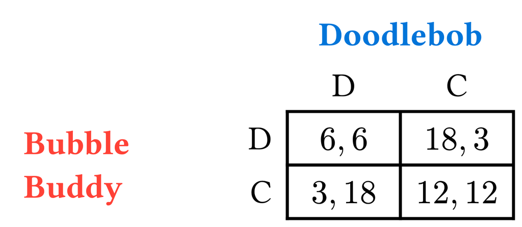

### Sol. 0

- Case 1 Payoffs
- Case 1 Analysis
- Case 2 Payoffs
- Case 2 Analysis
- Answer

Continue with Grim Trigger:
$$\begin{aligned}
\pi(s_{GT}, s_{GT})= 12 + 12\delta + 12\delta^2 + \cdots = \frac{12}{1-\delta}
\end{aligned}$$

Deviate once, then revert to G.T.:
$$\begin{aligned}
\pi(\hat{s}_{GT}, s_{GT})= 18 + 6\delta + 6\delta^2 + \cdots = 18 + \frac{6\delta}{1-\delta}
\end{aligned}$$

Maintain Grim Trigger when

$$\begin{aligned}
\frac{12}{1-\delta} &> 18 + \frac{6\delta}{1-\delta}\\
12 &> 18-18\delta+6\delta\\
12\delta &> 6\\
\delta &> \frac{1}{2}
\end{aligned}$$

Continue with Grim Trigger:
$$\begin{aligned}
\pi(s_{GT}, s_{GT})= 6 + 6\delta + 6\delta^2 + \cdots = \frac{6}{1-\delta}
\end{aligned}$$

Deviate once, then revert to G.T.:
$$\begin{aligned}
\pi(s_{GT}, s_{GT})= 3 + 6\delta + 6\delta^2 + \cdots = 3 + \frac{6\delta}{1-\delta}
\end{aligned}$$

Maintain G.T. when
$$\begin{aligned}
\frac{6}{1-\delta} &> 3 + \frac{6\delta}{1-\delta}\\
6 &> 3
\end{aligned}$$

- $\implies$ always

Cooperative play can be enforced when players are sufficiently patient ($\delta>0.5$)

### Ex. 1-2

1. Assume Mermaid Man and Barnacle Boy discount at different rates, $\delta_{MM}$ and $\delta_{BB}$. When can G.T. lead us to a coop. outcome?
2. Assume Mermaid Man and Barnacle Boy face the same probability that the game ends. When can G.T. enforce a coop outcome?

[figure not shown]

### Sol. 1

I’ll leave it to you to check the histories when $D\in\mathcal{H}$

- MM
- BB
- Ans

Assume $D\notin\mathcal{H}$

Assume $D\notin\mathcal{H}$

### Sol. 2

- Math doesn’t change; what does is the final “Answer” Step
- MM
- BB
- Ans

Assume $D\notin\mathcal{H}$

Assume $D\notin\mathcal{H}$

  $$\delta > 5/6$$

### Ex. 3

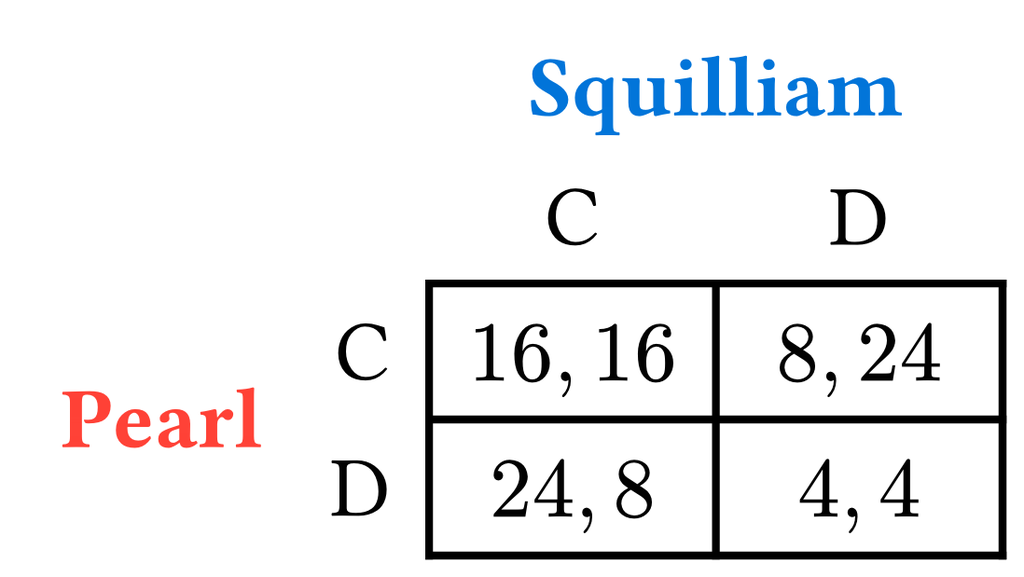

### Sol. 3

- Case 1
- Case 2
- Answer

$D \notin \mathcal{H}$

$D \in \mathcal{H}$

Maintain G.T. when
$$\begin{aligned}
\frac{4}{1-\delta} &> 8 + \frac{4\delta}{1-\delta}\\
4 &> 8
\end{aligned}$$

- $\implies$ *never*

We can’t enforce coopertive play using G.T.

- Why?
  - This isn’t a true PD: getting cheated is better than mutual defection

### Remarks (cont.)

- What happens if you get $\delta < 0$?
  - This means the assumed condition to get us to that point *never* happens
- What if you find $\delta > 1$?
  - Similar

### Remarks (cont.)

- What if you find $\delta < 2/3$ in the first history case, and $\delta\in [\frac{1}{4}, \frac{3}{4}]$ for the other?
  - To find when G.T. admits a cooperative SPNE, we need to combine these conditions:

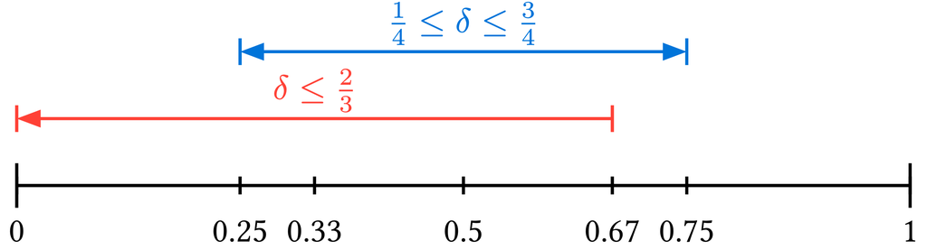

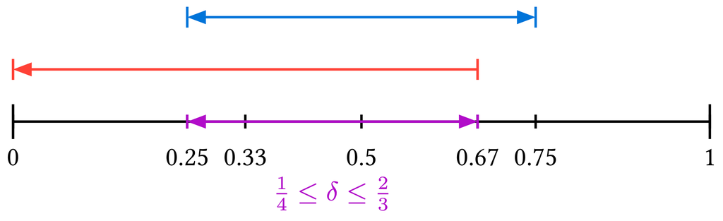

- - $\delta\in[\frac{1}{4}, \frac{2}{3}]$

### Remarks (cont.)

- What happens if you get $\delta < 0$?
  - This means the assumed condition to get us to that point *never* happens
- What if you find $\delta > 1$?
  - Similar
- What if you find $\delta < 2/3$ in the first history case, and $\delta\in [\frac{1}{4}, \frac{3}{4}]$ for the other?
  - To find when G.T. admits a cooperative SPNE, we need to combine these conditions
  - $\delta\in[\frac{1}{4}, \frac{2}{3}]$
- What if you end up with $\delta<1/4$ and $\delta>2/3$?
  - Again: impossible
- Use quantitative reasoning!

### Other interesting strategies

- Is grim trigger the only way to enforce the cooperative outcome?
  - As it turns out, no
- Tit-for-tat
- Pavlovs dogs (aka Win-Stay Lose-Switch)
- [Others](https://plato.stanford.edu/entries/prisoner-dilemma/strategy-table.html) (not all support cooperative play as a SPNE)

### Other games

- We ask similar questions about other simultaneous-move games played infinitely
- They are interesting, but we will restrict ourselves to PD (and similar) games, for the most part

## Quadratic Optimization

### :(

- Let $a<0$. Consider the function $f(x) = ax^2 + bx + c$
- Graphically, this is an upside-down parabola

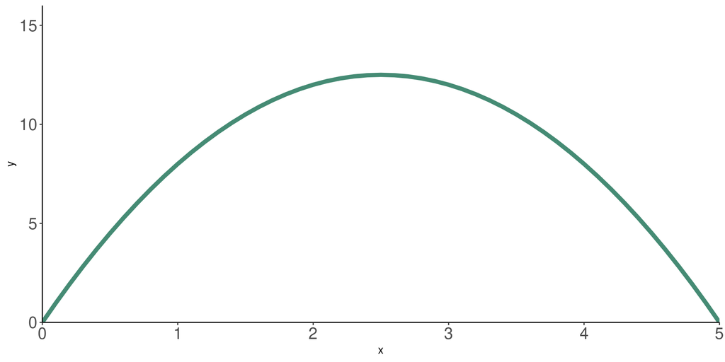

  $a = -2,\, b = 10,\, c = 0$

### :(

- Let $a<0$. Consider the function $f(x) = ax^2 + bx + c$
- Graphically, this is an upside-down parabola

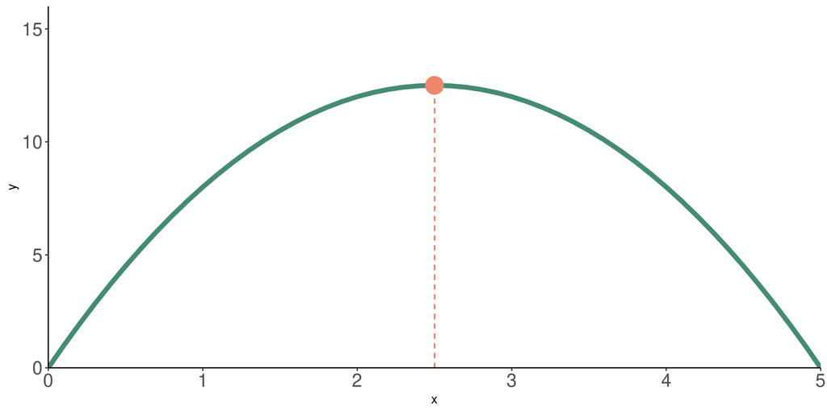

  $a = -2,\, b = 10,\, c = 0$

- For the next set of games we will be looking at, we need to know how to find the maximum value that this parabola obtains

### Remember the quadratic formula?

- For a quadratic given by $f(x) = ax^2 + bx + c$, the roots can be found using the quadratic formula:
  $$x = \frac{-b\pm \sqrt{b^2 - 4ac}}{2a}$$
  - This gives us the $\hat{x}$ values for which $f(\hat{x})=0$
- As it turns out, the $x^{*}$ value which maximizes $f(x)$ is halfway between these points
- Using some math, we can find the midpoint between the two roots
  - If $\hat{x}_1$ and $\hat{x}_2$ are the parabola’s roots (found via the quadratic equation), then

    $$x^{*}=\frac{1}{2}(\hat{x}_1 + \hat{x}_2) = -\frac{b}{2a}$$

### The maximum of a quadratic

- So, given a quadratic of the form $f(x) = ax^2 + bx + c$,
  - The value which maximizes $f$ (called the maximizer or arg. maximum), $x^{*}$, is given by
    $$x^{*}=\frac{-b}{2a}$$
  - The maximum *value* of $f$ is given by $f(x^{*})$
    - With some math, we can show that
      $$f(x^{*}) = c - \frac{b^2}{4a}$$
- Remark: you’re going to need to know how to get the maximum as well as the arg. max, so finding $x^{*}$ and plugging it in to $f$ is good practice

### Ex 0

- Recall our parabola from earlier: $f(x)=-2x^2+10x+0$
- The arg. max:
  $$\frac{-10}{2(-2)}=\frac{10}{4}=2.5$$
- The function’s maximum:

  $$f(x^{*})=-2(2.5)^2+10(2.5)=12.5$$

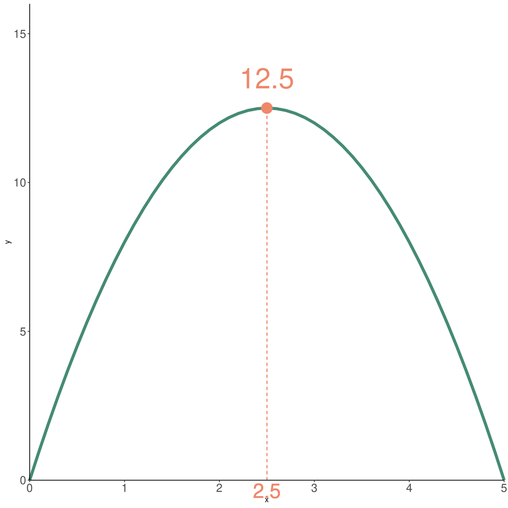

$f(x)=-2x^2 + 10x$

### Ex 1

- Let
  $$\pi = (100 - q_1 - q_2) q_1 - 10q_1$$
- Find the $q_1$ which maximizes $\pi$, and report the function maximum
- Rewrite $\pi$ as
  $$\pi(q_1) = -q_1^2 + (90 - q_2)q_1$$
- What’s $a$, $b$, and $c$?
  - $a=-1$, $b=90-q_2$, and $c=0$
- Therefore, the arg. max is given by

  $$q_1^{*}=\frac{-(90-q_2)}{-2}=\frac{90-q_2}{2}$$

### Ex 1 (solved)

- Let
  $$\pi = (100 - q_1 - q_2) q_1 - 10q_1$$
- Find the $q_1$ which maximizes $\pi$, and report the function maximum
- The arg. max is given by

  $$q_1^{*}=\frac{-(90-q_2)}{-2}=\frac{90-q_2}{2}$$
- The maximum $\pi$ is then given by

  $$\pi^{*}=-\frac{(90-q_2)^2}{-4}=\frac{(90-q_2)^{2}}{4}$$

### Alternative: Use Calculus

- If you have seen any introductory calculus, you can recall that we can just use the power rule and a bit of algebra to find the maximum of $f(x)=ax^2 + bx + c$
- [Kahn Academy on the Power Rule](https://www.khanacademy.org/math/old-ap-calculus-ab/ab-derivative-rules/ab-diff-negative-fraction-powers/a/power-rule-review)

  $$\frac{d}{dx}c\cdot x^n = c(n \cdot x^{n-1})$$
- So

  $$f'(x)=2ax + b$$
- To find the maximum (an extreme value), we set $f'(x)=0$:

  $$2ax+b=0\ \implies\ x=\frac{-b}{2a}$$

### Ex 2

- Let
  $$\pi = (100 - 2q_1 - q_2) q_1 - 25q_1 - 10$$
- Find the $q_1$ which maximizes $\pi$, and report the function maximum
- Rewrite $\pi$ as
  $$\pi(q_1) = -2q_1^2 + (75 - q_2)q_1 - 10$$
- What’s $\frac{d\pi}{dq_{1}}$?
  - $\pi'= -4q_1 + 75 - q_2$

### Ex 2 (Solved)

- To get the arg. max, set this $\pi'$ to 0 and solve for $q_1$:
  $$\begin{aligned}
  0 &= -4q_1 + 75 - q_2\\
  4q_1 &= 75 - q_2\\
  q_1^{*} &= \frac{75-q_2}{4}
  \end{aligned}$$
- The maximum $\pi$ is then given by

  $$\pi^{*}=-10 - \frac{(75 - q_2)^{2}}{4(-2)}=\frac{(75 - q_2)^{2}}{8} - 10$$

### Remarks

- I don’t care which one you use
- Using Calculus will also work for games with more complex payoff functions<sup>1</sup>
[^3]: We will restrict ourselves to quadratics